# Chapter 04 Exercises

## 4.6 Exercises

1. Write a function to compute the mean and standard deviation of a time series, and apply it to the PBS data. Plot the series with the highest mean, and the series with the lowest standard deviation.

```r
PBS %>%
  as_tibble()%>%
  group_by(ATC1_desc) %>%
  summarize(Avg_Cost = mean(Cost),
            Std_Cost = sd(Cost)) %>%
  arrange(desc(Avg_Cost))
```

```
## # A tibble: 15 x 3
##    ATC1_desc                                                   Avg_Cost Std_Cost
##    <chr>                                                          <dbl>    <dbl>
##  1 Cardiovascular system                                       2594071. 6471171.
##  2 Nervous system                                              1985150. 3748857.
##  3 Antineoplastic and immunomodulating agents                  1386001. 2178577.
##  4 Respiratory system                                          1308753. 3466564.
##  5 Alimentary tract and metabolism                              924237. 3011654.
##  6 Musculo-skeletal system                                      780143. 2039964.
##  7 Antiinfectives for systemic use                              734496. 1781448.
##  8 Genito urinary system and sex hormones                       478357. 1107672.
##  9 Blood and blood forming organs                               444450. 1616023.
## 10 Sensory organs                                               409280. 1246218.
## 11 Various                                                      140458.  291258.
## 12 Dermatologicals                                              125144.  283694.
## 13 Systemic hormonal preparations, excl. sex hormones and ins~   81698.  150833.
## 14 Antiparasitic products, insecticides and repellents           27123.   64686.
## 15 <NA>                                                          15078.   45375.
```

- Series with the highest mean: Cardiovascular System
- Series with the lowest standard deviation: Antiparasitic products, insecticides and repellents

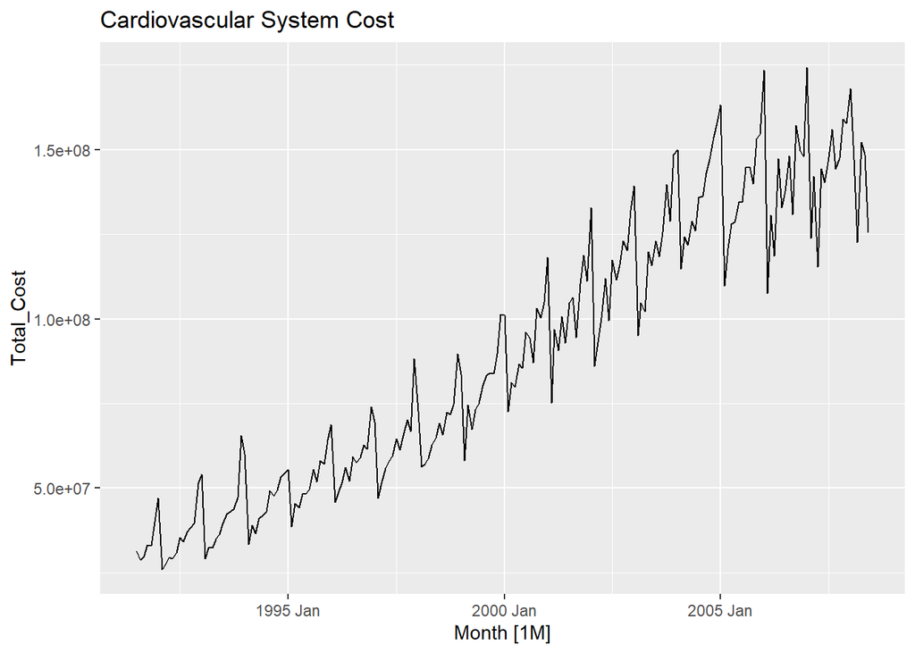

```r
PBS %>%
  group_by(ATC1_desc) %>%
  filter(ATC1_desc == 'Cardiovascular system') %>%
  summarize(Total_Cost = sum(Cost)) %>%
  autoplot(Total_Cost) +
  labs(title = "Cardiovascular System Cost")
```

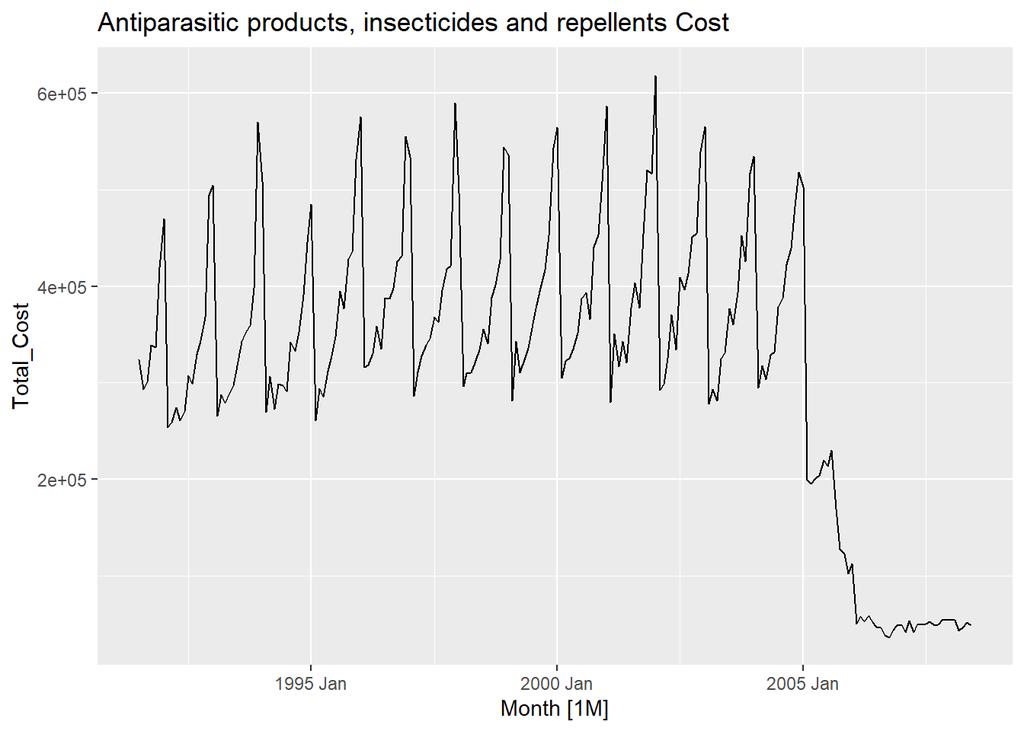

```r
PBS %>%
  group_by(ATC1_desc) %>%
  filter(ATC1_desc == 'Antiparasitic products, insecticides and repellents') %>%
  summarize(Total_Cost = sum(Cost)) %>%
  autoplot(Total_Cost) +
  labs(title = "Antiparasitic products, insecticides and repellents Cost")
```

2. Use GGally::ggpairs() to look at the relationships between the STL-based features for the holiday series in the tourism data. Change seasonal_peak_year and seasonal_trough_year to factors, as shown in Figure 4.3. Which is the peak quarter for holidays in each state?

```r
holiday_series <- tourism %>%
  filter(Purpose == 'Holiday')

holiday_series_features <- holiday_series %>%
  features(Trips, feature_set(pkgs = 'feasts'))
```

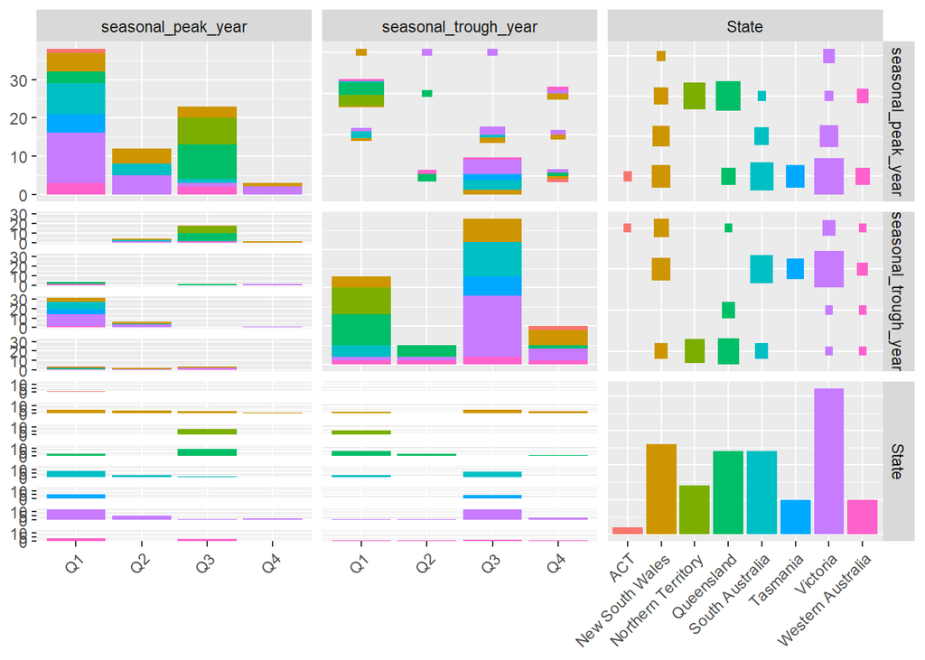

```r
holiday_series_features %>%
  select(seasonal_peak_year, seasonal_trough_year, State) %>%
  mutate(
    seasonal_peak_year = seasonal_peak_year +
      4*(seasonal_peak_year == 0),
    seasonal_trough_year = seasonal_trough_year +
      4*(seasonal_trough_year == 0),
    seasonal_peak_year = glue('Q{seasonal_peak_year}'),
    seasonal_trough_year =glue('Q{seasonal_trough_year}'),
  ) %>%
  ggpairs(mapping = aes(color = State)) +
  theme(axis.text.x.bottom = element_text(angle=45, hjust=1))
```

ACT, NSW, South Australia, Tasmania, Victoria, Western Australia peak in Q1 Nothern Territory and Queensland peak in Q3

3. Use a feature-based approach to look for outlying series in the PBS data. What is unusual about the series you identify as “outliers.”

```r
PBS
```

```
## # A tsibble: 67,596 x 9 [1M]
## # Key:       Concession, Type, ATC1, ATC2 [336]
##       Month Concession  Type   ATC1  ATC1_desc   ATC2  ATC2_desc   Scripts  Cost
##       <mth> <chr>       <chr>  <chr> <chr>       <chr> <chr>         <dbl> <dbl>
##  1 1991 Jul Concession~ Co-pa~ A     Alimentary~ A01   STOMATOLOG~   18228 67877
##  2 1991 Aug Concession~ Co-pa~ A     Alimentary~ A01   STOMATOLOG~   15327 57011
##  3 1991 Sep Concession~ Co-pa~ A     Alimentary~ A01   STOMATOLOG~   14775 55020
##  4 1991 Oct Concession~ Co-pa~ A     Alimentary~ A01   STOMATOLOG~   15380 57222
##  5 1991 Nov Concession~ Co-pa~ A     Alimentary~ A01   STOMATOLOG~   14371 52120
##  6 1991 Dec Concession~ Co-pa~ A     Alimentary~ A01   STOMATOLOG~   15028 54299
##  7 1992 Jan Concession~ Co-pa~ A     Alimentary~ A01   STOMATOLOG~   11040 39753
##  8 1992 Feb Concession~ Co-pa~ A     Alimentary~ A01   STOMATOLOG~   15165 54405
##  9 1992 Mar Concession~ Co-pa~ A     Alimentary~ A01   STOMATOLOG~   16898 61108
## 10 1992 Apr Concession~ Co-pa~ A     Alimentary~ A01   STOMATOLOG~   18141 65356
## # ... with 67,586 more rows
```

```r
pbs_features <- PBS %>%
  features(Scripts, feature_set(pkgs = 'feasts'))
```

```
## Error in ar.burg.default(x, aic = aic, order.max = order.max, na.action = na.action,  :
##   zero-variance series
## Error in ar.burg.default(x, aic = aic, order.max = order.max, na.action = na.action,  :
##   zero-variance series
```

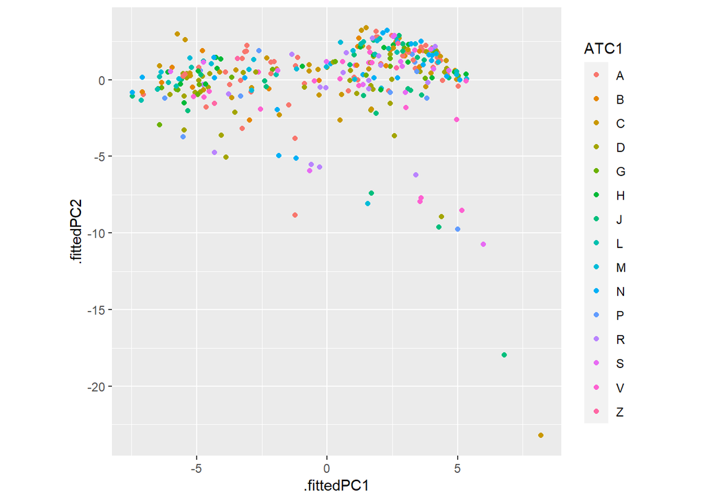

```r
pbs_features <- pbs_features %>%
  drop_na()

pca <- pbs_features %>%
  select(-Concession, -Type, -ATC1, -ATC2) %>%
  prcomp(scale = TRUE) %>%
  augment(pbs_features)

pca %>%
  ggplot(aes(x = .fittedPC1, y = .fittedPC2, col = ATC1)) +
  geom_point() +
  theme(aspect.ratio = 1)
```

We can see there are outliers here in the bottom right corner.

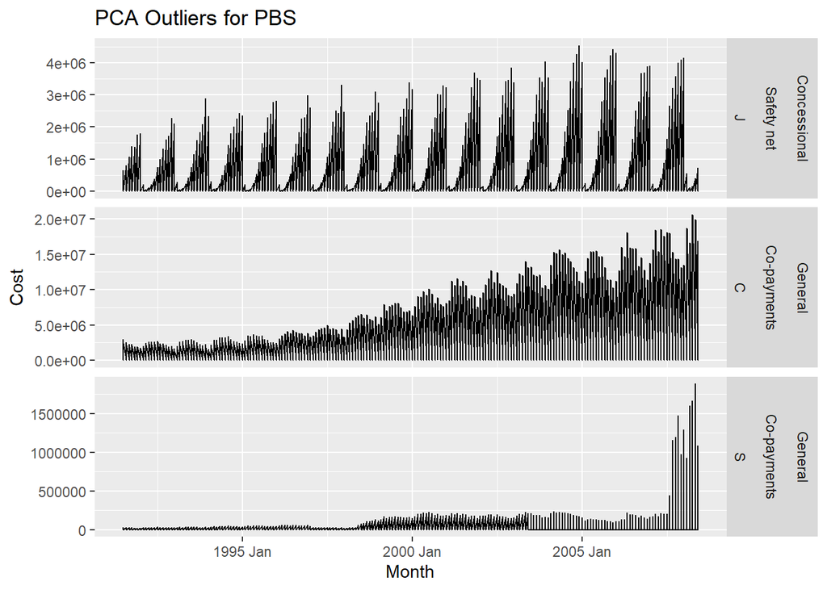

```r
outliers <- pca %>%
  filter(.fittedPC2 < -10) %>%
  select(Concession, Type, ATC1)

outliers %>%
  left_join(PBS, by = c("Concession", "Type","ATC1")) %>%
  mutate(
    Series = glue("{Concession}","{Type}","{ATC1}", .sep = '\n\n')
  ) %>%
  ggplot(aes(x = Month, y=Cost)) +
  geom_line() +
  facet_grid(Series ~ ., scales = 'free') +
  labs(title = "PCA Outliers for PBS")
```

I have tried the cost and the total scripts variables and I am still unsure as to why these are outliers. Possible reasons:

- J: high seasonality and increasing variance but always falling back to 0 on the dips
- C: some seasonality and upward trend
- S: large volume increase towards the end of the series